# Analyzing the Words People Use to Describe Their Happy Moments

Jianjie Sun

2023-09-25

```r
# Load package
library(tm)
library(tidytext)
library(tidyverse)
```

```r
library(wordcloud2)
library(ggplot2)
library(DT)
```

**Introduction**

Understanding what makes people happy is essential to augment positive experiences. HappyDB, a crowd-sourced collection of 100,000 happy moments is the data set which I focus on in this project. My goal is to build a EDA that understands how people express their happiness in text while achieving insights into happiness-leading events and scenarios on a scale.

```r
# Read data
# hm for cleaned_hm.csv
# demo for demographic.csv
hm_path <- "C:/Users/Jay S/Desktop/Columbia/5243 Applied Data Science/5243 Project1/cleaned_hm.csv"
demo_path <- "C:/Users/Jay S/Desktop/Columbia/5243 Applied Data Science/5243 Project1/demographic.csv"

hm_data <- read_csv(hm_path)
demo_data <- read_csv(demo_path)
```

**Data Cleaning and Data Mining**

```r
# Text preprocessing
corpus <- VCorpus(VectorSource(hm_data$cleaned_hm)) %>%
  tm_map(content_transformer(tolower)) %>%
  tm_map(removePunctuation) %>%
  tm_map(removeNumbers) %>%
  tm_map(removeWords, stopwords("en")) %>%
  tm_map(stripWhitespace)
```

```r
# Stemming and tokenizing
stemmed <- tm_map(corpus, stemDocument) %>%
  tidy() %>%
  select(text)

dict <- tidy(corpus) %>%
  select(text) %>%
  unnest_tokens(dictionary, text)
extra_stop_words <- c("happy","ago","yesterday","lot","today","months","month",
                      "happier","happiest","last","week","past")
stop_words <- stop_words %>% bind_rows(tibble(word = extra_stop_words, lexicon = "custom"))

completed <- stemmed %>%
  mutate(id = row_number()) %>%
  unnest_tokens(stems, text) %>%
  bind_cols(dict) %>%
  anti_join(stop_words, by = c("dictionary" = "word"))
completed_final <- completed %>%
  group_by(stems) %>%
  count(dictionary) %>%
  mutate(word = dictionary[which.max(n)]) %>%
  ungroup() %>%
  select(stems, word) %>%
  distinct()

completed_final <- completed_final %>%
  right_join(completed, by = "stems") %>%
  select(-stems) %>%
  group_by(id) %>%
  summarise(text = str_c(word, collapse = " ")) %>%
  ungroup()
```

```r
# Merge with original data
hm_data <- hm_data %>%
  mutate(id = row_number()) %>%
  inner_join(completed_final, by = "id")
head(hm_data)
```

```
## # A tibble: 6 × 11
##    hmid   wid reflection_period original_hm     cleaned_hm modified num_sentence
##   <dbl> <dbl> <chr>             <chr>           <chr>      <lgl>           <dbl>
## 1 27673  2053 24h               "I went on a s… "I went o… TRUE                1
## 2 27674     2 24h               "I was happy w… "I was ha… TRUE                1
## 3 27675  1936 24h               "I went to the… "I went t… TRUE                1
## 4 27676   206 24h               "We had a seri… "We had a… TRUE                2
## 5 27677  6227 24h               "I went with g… "I went w… TRUE                1
## 6 27678    45 24h               "I meditated l… "I medita… TRUE                1
## # ℹ 4 more variables: ground_truth_category <chr>, predicted_category <chr>,
## #   id <int>, text <chr>
```

```r
# Function to count words in a text string
word_count <- function(text) {
  sum(str_count(text, "\\S+"))
}
```

```r
# Process and filter data
hm_data <- hm_data %>%
  inner_join(demo_data, by = "wid") %>%
  select(
    wid,
    original_hm,
    gender,
    marital,
    parenthood,
    reflection_period,
    age,
    country,
    ground_truth_category,
    text
  ) %>%
  mutate(count = str_count(text, "\\S+")) %>%
  filter(
    gender %in% c("m", "f"),
    marital %in% c("single", "married"),
    parenthood %in% c("n", "y"),
    reflection_period %in% c("24h", "3m")
  ) %>%
  mutate(reflection_period = fct_recode(reflection_period, months_3 = "3m", hours_24 = "24h"))

head(hm_data)
```

```
## # A tibble: 6 × 11
##     wid original_hm    gender marital parenthood reflection_period   age country
##   <dbl> <chr>          <chr>  <chr>   <chr>      <fct>             <dbl> <chr>
## 1  2053 I went on a s… m      single  n          hours_24             35 USA
## 2     2 I was happy w… m      married y          hours_24             29 IND
## 3  1936 I went to the… f      married y          hours_24             30 USA
## 4   206 We had a seri… f      married n          hours_24             28 DNK
## 5    45 I meditated l… m      single  n          hours_24             23 IND
## 6   195 I made a new … m      single  n          hours_24             30 USA
## # ℹ 3 more variables: ground_truth_category <chr>, text <chr>, count <int>
```

```r
# Create Bag of Words
bag_of_words <- hm_data %>%
  unnest_tokens(word, text)

word_count <- bag_of_words %>%
  count(word, sort = TRUE)

hm_bigrams <- hm_data %>%
  unnest_tokens(bigram, text, token = "ngrams", n = 2)

bigram_counts <- hm_bigrams %>%
  separate(bigram, c("word1", "word2"), sep = " ") %>%
  count(word1, word2, sort = TRUE) %>%
  filter(n > 1)

wc <- word_count %>% filter(n > 3100)
```

**Visualization and Interpretation**

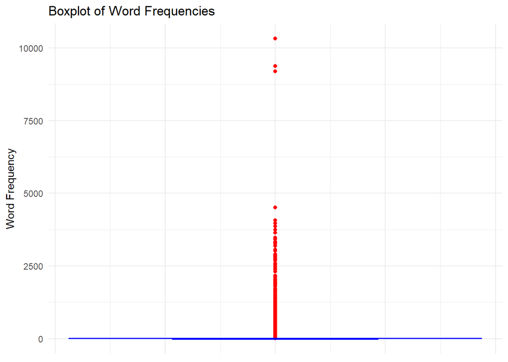

```r
# Create plots
ggplot(data = word_count, aes(y = n)) +
  geom_boxplot(fill = "lightblue", color = "blue", outlier.color = "red", notch = TRUE) +
  ylab('Word Frequency') +
  ggtitle('Boxplot of Word Frequencies') +
  theme_minimal() +
  theme(axis.text.x = element_blank(),
        legend.position = "none")
```

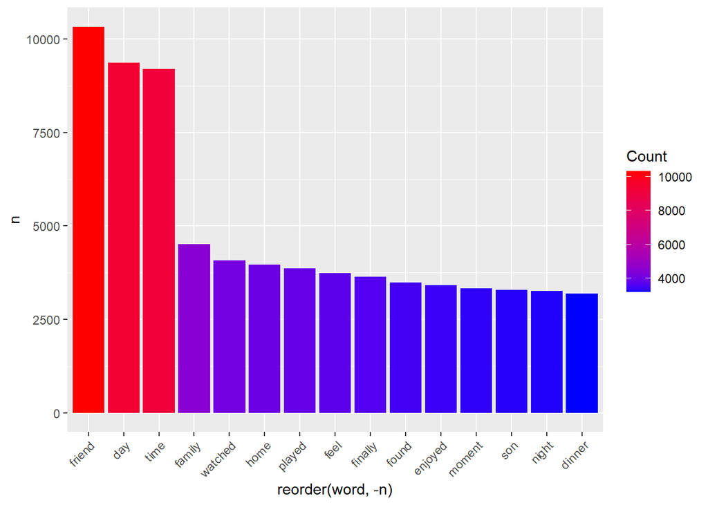

```r
ggplot(data = wc, aes(x = reorder(word, -n), y = n, fill = n)) +
  geom_bar(stat = "identity") +
  scale_fill_gradient("Count", low = "blue", high = "red") +
  theme(axis.text.x = element_text(angle = 45, hjust = 1))
```

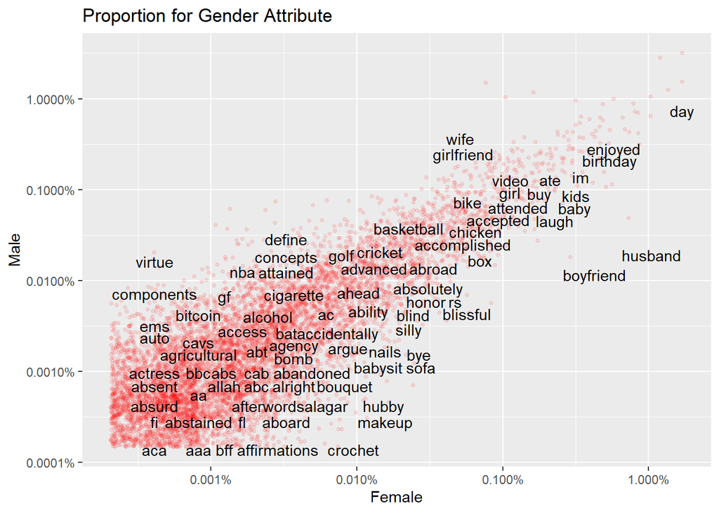

```r
#From the plot we can easily see that the words which people pick most frequently when they are happy.
library(scales)
library(ngram)
library(shiny)
library(gridExtra)
attribute_gender_data = bag_of_words %>%
      count(gender, word) %>%
      group_by(gender) %>%
      mutate(proportion = n / sum(n)) %>%
      select(-n) %>%
      spread(gender, proportion)

attribute_gender = ggplot(attribute_gender_data,
             aes_string(x = colnames(attribute_gender_data)[2],
                        y = colnames(attribute_gender_data)[3]),
             colour = abs(colnames(attribute_gender_data)[3] - colnames(attribute_gender_data)[2])) +
      geom_jitter(alpha = 0.1, size = 1, width = 0.3, height = 0.3, colour = "red") +
      geom_text(aes(label = word), check_overlap = TRUE, vjust = 3) +
      ggtitle("Proportion for Gender Attribute") +
      xlab("Female") + ylab("Male") +
      scale_x_log10(labels = percent_format()) +
      scale_y_log10(labels = percent_format()) +
      theme(legend.position="none")
print(attribute_gender)
```

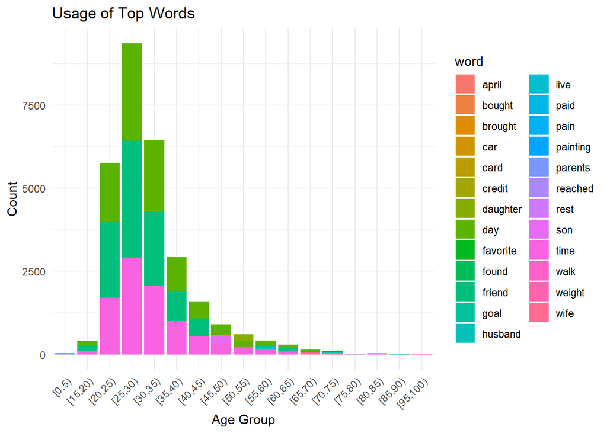

```r
# Top 3 most frequent words used within each age groups
if (all(c("age", "word") %in% names(bag_of_words))) {

  processed <- bag_of_words %>%
    select(age, word) %>%
    mutate(age_group = cut(age, seq(0, 100, by = 5), right = FALSE)) %>%
    count(age_group, word, name = "count") %>%
    arrange(desc(count))

  top_words <- processed %>%
    group_by(age_group) %>%
    slice_max(order_by = count, n = 3) %>%
    ungroup()

  filtered_top_words <- top_words %>%
    group_by(age_group) %>%
    filter(sum(count) > 0, !is.na(age_group)) %>%
    ungroup()

  p <- ggplot(filtered_top_words, aes(x = age_group, y = count, fill = word)) +
    geom_bar(stat = "identity") +
    labs(title = "Usage of Top Words",
         x = "Age Group",
         y = "Count") +
    theme_minimal() +
    theme(axis.text.x = element_text(angle = 45, hjust = 1))
  print(p)

} else {
  message("The required columns (age and word) are not present in the bag_of_words data frame.")
}
```

From the plot, it’s evident that the frequency of happy words varies significantly across different age groups. Furthermore, certain words maintain a high usage rate across a broad age range, suggesting that while happiness is a complex emotional state influenced by various factors, there are universally resonant words that are commonly associated with joy.

**Summary**

The factors that contribute to happiness are diverse and multifaceted, encompassing elements such as social connections, personal achievements, career fulfillment, leisure activities, and individual preferences. Furthermore, what captures people’s attention and brings them joy is not static but evolves over time, adapting to life’s changing circumstances and stages.